# Project 2 (Investigate a Dataset): TMDb Movie Data Analysis

- Introduction
- Data Wrangling
- Exploratory Data Analysis
- Conclusions

## Introduction

>

> To perform this data analysis, I'm using TMDb movie data (cleaned from original data on Kaggle). This dataset contains information about 10,000 movies collected from The Movie Database (TMDb), including user ratings and revenue. I'm using Python libraries NumPy, pandas, seaborn, and Matplotlib packages and will include visualizations to aid understanding of the data.

> **Questions:**
> 1. How popular from year-to-year were the most frequently-made movie genres?
> 2. Which movie genres had the highest revenues?
> 3. Which director made the most movies?
> 4. What movies had the greatest return on investment?
> 5. Is there a relationship between movie popularity, return on investment, and genre?

```python
# Import packages
import pandas as pd
import numpy as np
import seaborn as sns
import matplotlib.pyplot as plt
% matplotlib inline
```

## Data Wrangling

### General Properties

```python
# Loading the dataset tmdb-movies.csv
df = pd.read_csv('tmdb-movies.csv')

# View the first five rows of dataset
df.head()
```

|  | id | imdb_id | popularity | budget | revenue | original_title | cast | homepage | director | tagline | ... | overview | runtime | genres | production_companies | release_date | vote_count | vote_average | release_year | budget_adj | revenue_adj |
| --- | --- | --- | --- | --- | --- | --- | --- | --- | --- | --- | --- | --- | --- | --- | --- | --- | --- | --- | --- | --- | --- |
| 0 | 135397 | tt0369610 | 32.985763 | 150000000 | 1513528810 | Jurassic World | Chris Pratt\|Bryce Dallas Howard\|Irrfan Khan\|Vi... | http://www.jurassicworld.com/ | Colin Trevorrow | The park is open. | ... | Twenty-two years after the events of Jurassic ... | 124 | Action\|Adventure\|Science Fiction\|Thriller | Universal Studios\|Amblin Entertainment\|Legenda... | 6/9/15 | 5562 | 6.5 | 2015 | 1.379999e+08 | 1.392446e+09 |
| 1 | 76341 | tt1392190 | 28.419936 | 150000000 | 378436354 | Mad Max: Fury Road | Tom Hardy\|Charlize Theron\|Hugh Keays-Byrne\|Nic... | http://www.madmaxmovie.com/ | George Miller | What a Lovely Day. | ... | An apocalyptic story set in the furthest reach... | 120 | Action\|Adventure\|Science Fiction\|Thriller | Village Roadshow Pictures\|Kennedy Miller Produ... | 5/13/15 | 6185 | 7.1 | 2015 | 1.379999e+08 | 3.481613e+08 |
| 2 | 262500 | tt2908446 | 13.112507 | 110000000 | 295238201 | Insurgent | Shailene Woodley\|Theo James\|Kate Winslet\|Ansel... | http://www.thedivergentseries.movie/#insurgent | Robert Schwentke | One Choice Can Destroy You | ... | Beatrice Prior must confront her inner demons ... | 119 | Adventure\|Science Fiction\|Thriller | Summit Entertainment\|Mandeville Films\|Red Wago... | 3/18/15 | 2480 | 6.3 | 2015 | 1.012000e+08 | 2.716190e+08 |
| 3 | 140607 | tt2488496 | 11.173104 | 200000000 | 2068178225 | Star Wars: The Force Awakens | Harrison Ford\|Mark Hamill\|Carrie Fisher\|Adam D... | http://www.starwars.com/films/star-wars-episod... | J.J. Abrams | Every generation has a story. | ... | Thirty years after defeating the Galactic Empi... | 136 | Action\|Adventure\|Science Fiction\|Fantasy | Lucasfilm\|Truenorth Productions\|Bad Robot | 12/15/15 | 5292 | 7.5 | 2015 | 1.839999e+08 | 1.902723e+09 |
| 4 | 168259 | tt2820852 | 9.335014 | 190000000 | 1506249360 | Furious 7 | Vin Diesel\|Paul Walker\|Jason Statham\|Michelle ... | http://www.furious7.com/ | James Wan | Vengeance Hits Home | ... | Deckard Shaw seeks revenge against Dominic Tor... | 137 | Action\|Crime\|Thriller | Universal Pictures\|Original Film\|Media Rights ... | 4/1/15 | 2947 | 7.3 | 2015 | 1.747999e+08 | 1.385749e+09 |

5 rows × 21 columns

```python
# View number of rows and columns in dataset
df.shape
```

```
(10866, 21)
```

```python
# View summary statistics
df.describe()
```

|  | id | popularity | budget | revenue | runtime | vote_count | vote_average | release_year | budget_adj | revenue_adj |
| --- | --- | --- | --- | --- | --- | --- | --- | --- | --- | --- |
| count | 10866.000000 | 10866.000000 | 1.086600e+04 | 1.086600e+04 | 10866.000000 | 10866.000000 | 10866.000000 | 10866.000000 | 1.086600e+04 | 1.086600e+04 |
| mean | 66064.177434 | 0.646441 | 1.462570e+07 | 3.982332e+07 | 102.070863 | 217.389748 | 5.974922 | 2001.322658 | 1.755104e+07 | 5.136436e+07 |
| std | 92130.136561 | 1.000185 | 3.091321e+07 | 1.170035e+08 | 31.381405 | 575.619058 | 0.935142 | 12.812941 | 3.430616e+07 | 1.446325e+08 |
| min | 5.000000 | 0.000065 | 0.000000e+00 | 0.000000e+00 | 0.000000 | 10.000000 | 1.500000 | 1960.000000 | 0.000000e+00 | 0.000000e+00 |
| 25% | 10596.250000 | 0.207583 | 0.000000e+00 | 0.000000e+00 | 90.000000 | 17.000000 | 5.400000 | 1995.000000 | 0.000000e+00 | 0.000000e+00 |
| 50% | 20669.000000 | 0.383856 | 0.000000e+00 | 0.000000e+00 | 99.000000 | 38.000000 | 6.000000 | 2006.000000 | 0.000000e+00 | 0.000000e+00 |
| 75% | 75610.000000 | 0.713817 | 1.500000e+07 | 2.400000e+07 | 111.000000 | 145.750000 | 6.600000 | 2011.000000 | 2.085325e+07 | 3.369710e+07 |
| max | 417859.000000 | 32.985763 | 4.250000e+08 | 2.781506e+09 | 900.000000 | 9767.000000 | 9.200000 | 2015.000000 | 4.250000e+08 | 2.827124e+09 |

```python
# View dataset info
df.info()
```

```
<class 'pandas.core.frame.DataFrame'>
RangeIndex: 10866 entries, 0 to 10865
Data columns (total 21 columns):
id                      10866 non-null int64
imdb_id                 10856 non-null object
popularity              10866 non-null float64
budget                  10866 non-null int64
revenue                 10866 non-null int64
original_title          10866 non-null object
cast                    10790 non-null object
homepage                2936 non-null object
director                10822 non-null object
tagline                 8042 non-null object
keywords                9373 non-null object
overview                10862 non-null object
runtime                 10866 non-null int64
genres                  10843 non-null object
production_companies    9836 non-null object
release_date            10866 non-null object
vote_count              10866 non-null int64
vote_average            10866 non-null float64
release_year            10866 non-null int64
budget_adj              10866 non-null float64
revenue_adj             10866 non-null float64
dtypes: float64(4), int64(6), object(11)
memory usage: 1.7+ MB
```

### Initial Observation From The Dataset

> - This is a large dataset, it looks like I can remove a few unnecessary columns for this analysis (including coulmns that seem to be missing large amounts of data).
> - It looks like there are some missing values or areas that are marked by '0', this will need further investigation.
> - There are some columns that contain special character: '|', that should be separated out.

### Data Cleaning

> 1. Remove duplicate rows (if any) from the dataset.
> 2. Remove any unnecessary columns for this analysis: '**id**','**imdb_id**','**homepage**','**tagline**','**keywords**','**overview**','**budget_adj**','**revenue_adj**'
> 3. Remove rows that have zero value for budget and revenue.
> 4. Convert release_date column from string to datetime.

#### 1. Determine/Remove Any Duplicate Rows

```python
# Determine if there are duplicated rows related to the id column
df[df.duplicated(['id'], keep=False)]
```

|  | id | imdb_id | popularity | budget | revenue | original_title | cast | homepage | director | tagline | ... | overview | runtime | genres | production_companies | release_date | vote_count | vote_average | release_year | budget_adj | revenue_adj |
| --- | --- | --- | --- | --- | --- | --- | --- | --- | --- | --- | --- | --- | --- | --- | --- | --- | --- | --- | --- | --- | --- |
| 2089 | 42194 | tt0411951 | 0.59643 | 30000000 | 967000 | TEKKEN | Jon Foo\|Kelly Overton\|Cary-Hiroyuki Tagawa\|Ian... | NaN | Dwight H. Little | Survival is no game | ... | In the year of 2039, after World Wars destroy ... | 92 | Crime\|Drama\|Action\|Thriller\|Science Fiction | Namco\|Light Song Films | 3/20/10 | 110 | 5.0 | 2010 | 30000000.0 | 967000.0 |
| 2090 | 42194 | tt0411951 | 0.59643 | 30000000 | 967000 | TEKKEN | Jon Foo\|Kelly Overton\|Cary-Hiroyuki Tagawa\|Ian... | NaN | Dwight H. Little | Survival is no game | ... | In the year of 2039, after World Wars destroy ... | 92 | Crime\|Drama\|Action\|Thriller\|Science Fiction | Namco\|Light Song Films | 3/20/10 | 110 | 5.0 | 2010 | 30000000.0 | 967000.0 |

2 rows × 21 columns

```python
# Drop duplicate data
df.drop_duplicates(inplace=True)
```

```python
# Check for accuarcy after removing duplicate data, this should return 0 rows of duplicate data
df[df.duplicated(['id'], keep=False)]
```

|  | id | imdb_id | popularity | budget | revenue | original_title | cast | homepage | director | tagline | ... | overview | runtime | genres | production_companies | release_date | vote_count | vote_average | release_year | budget_adj | revenue_adj |
| --- | --- | --- | --- | --- | --- | --- | --- | --- | --- | --- | --- | --- | --- | --- | --- | --- | --- | --- | --- | --- | --- |

0 rows × 21 columns

#### 2. Remove Any Unnecessary Columns

```python
# Drop unnecessary columns
df.drop(['id','imdb_id','homepage','tagline','keywords','overview','budget_adj','revenue_adj'], axis=1, inplace=True)

# These are columns that I didn't find relevant to the questions that I'm attempting to answer,
# therefore, I'll remove them from the dataset to make my work space cleaner/quicker to access
```

```python
# View number of rows and columns in dataset
df.shape
```

```
(10865, 13)
```

```python
# View dataset info
df.info()
```

```
<class 'pandas.core.frame.DataFrame'>
Int64Index: 10865 entries, 0 to 10865
Data columns (total 13 columns):
popularity              10865 non-null float64
budget                  10865 non-null int64
revenue                 10865 non-null int64
original_title          10865 non-null object
cast                    10789 non-null object
director                10821 non-null object
runtime                 10865 non-null int64
genres                  10842 non-null object
production_companies    9835 non-null object
release_date            10865 non-null object
vote_count              10865 non-null int64
vote_average            10865 non-null float64
release_year            10865 non-null int64
dtypes: float64(2), int64(5), object(6)
memory usage: 1.2+ MB
```

##### Determine if the production_companies column should be removed

```python
# View the summary statistics of revenue where production_companies contain null values
df[df['production_companies'].isnull()]['revenue'].describe().apply(lambda r: format(r, 'f'))
```

```
count        1030.000000
mean       466828.406796
std       3813520.884754
min             0.000000
25%             0.000000
50%             0.000000
75%             0.000000
max      76000000.000000
Name: revenue, dtype: object
```

```python
# View the rows that have a max revenue value of 76000000
df[df['revenue'] == 76000000]
```

|  | popularity | budget | revenue | original_title | cast | director | runtime | genres | production_companies | release_date | vote_count | vote_average | release_year |
| --- | --- | --- | --- | --- | --- | --- | --- | --- | --- | --- | --- | --- | --- |
| 3235 | 0.21503 | 9100000 | 76000000 | Ghajini | Aamir Khan\|Asin Thottumkal\|Jiah Khan\|Pradeep R... | A.R. Murugadoss | 183 | Action\|Drama\|Foreign\|Mystery\|Thriller | NaN | 12/25/08 | 53 | 6.9 | 2008 |
| 9152 | 0.26504 | 27000000 | 76000000 | The Newton Boys | Matthew McConaughey\|Skeet Ulrich\|Ethan Hawke\|V... | Richard Linklater | 113 | Crime\|Action\|Drama | Twentieth Century Fox Film Corporation\|Detour ... | 3/26/98 | 16 | 6.4 | 1998 |

```python
# View the summary statistics of revenue where production_companies does not contain null values
df[df['production_companies'].notnull()]['revenue'].describe().apply(lambda r: format(r, 'f'))
```

```
count          9835.000000
mean       43948997.724047
std       122246184.135205
min               0.000000
25%               0.000000
50%               0.000000
75%        30497323.000000
max      2781505847.000000
Name: revenue, dtype: object
```

```python
# View the rows that have a max revenue value of 2781505847
df[df['revenue'] == 2781505847]
```

|  | popularity | budget | revenue | original_title | cast | director | runtime | genres | production_companies | release_date | vote_count | vote_average | release_year |
| --- | --- | --- | --- | --- | --- | --- | --- | --- | --- | --- | --- | --- | --- |
| 1386 | 9.432768 | 237000000 | 2781505847 | Avatar | Sam Worthington\|Zoe Saldana\|Sigourney Weaver\|S... | James Cameron | 162 | Action\|Adventure\|Fantasy\|Science Fiction | Ingenious Film Partners\|Twentieth Century Fox ... | 12/10/09 | 8458 | 7.1 | 2009 |

##### I decided to leave in the production_companies column

> After performing an exploratory data analysis, I decided to keep the production_companies column as a part of the dataset rather than remove it. I was originally thinking that production_companies column should be removed since it contains a lot of null values in the revenue column, however, upon further inspection it seems to provide an interestesting insight into high revenue value movies. We can guess that the movies that don't have a production company listed are smaller more independent films and therefore would not have a high revenue return as some of the other more well known production companies with a higher budget and resources.

#### 3. Remove Rows w/Zero Value for Budget/Revenue

```python
# Remove rows with zero value in the budget and revenue fields
# Create a new list, tmdb_df, to house the remaining data
tmdb_df = df[(df['budget'] != 0) & (df['revenue'] != 0)]
print(tmdb_df.shape)
```

```
(3854, 13)
```

```python
# View the first five rows of dataset
tmdb_df.head(1)
```

[output not shown]

#### 4. Change the Release Date Column to Datetime Format

```python
pd.options.mode.chained_assignment = None # Ignore chaining errors.
# Change release date to datetime format
tmdb_df.loc[:,'release_date'] = pd.to_datetime(tmdb_df['release_date'])

# View the first row of dataset
tmdb_df.head(1)
```

|  | popularity | budget | revenue | original_title | cast | director | runtime | genres | production_companies | release_date | vote_count | vote_average | release_year |
| --- | --- | --- | --- | --- | --- | --- | --- | --- | --- | --- | --- | --- | --- |
| 0 | 32.985763 | 150000000 | 1513528810 | Jurassic World | Chris Pratt\|Bryce Dallas Howard\|Irrfan Khan\|Vi... | Colin Trevorrow | 124 | Action\|Adventure\|Science Fiction\|Thriller | Universal Studios\|Amblin Entertainment\|Legenda... | 2015-06-09 | 5562 | 6.5 | 2015 |

```python
# View dataset info
tmdb_df.info()
```

```
<class 'pandas.core.frame.DataFrame'>
Int64Index: 3854 entries, 0 to 10848
Data columns (total 13 columns):
popularity              3854 non-null float64
budget                  3854 non-null int64
revenue                 3854 non-null int64
original_title          3854 non-null object
cast                    3850 non-null object
director                3853 non-null object
runtime                 3854 non-null int64
genres                  3854 non-null object
production_companies    3808 non-null object
release_date            3854 non-null datetime64[ns]
vote_count              3854 non-null int64
vote_average            3854 non-null float64
release_year            3854 non-null int64
dtypes: datetime64[ns](1), float64(2), int64(5), object(5)
memory usage: 421.5+ KB
```

## Exploratory Data Analysis

### 1. How popular from year-to-year were the most frequently-made movie genres?

```python
# SPLIT_COUNTER FUNCTION: Created a function to look in a specific column (e.i. 'genres, 'director')
# and split/separate out the bar '|' symbol in rows where it occurs, appends to the list the varible
# remaining and returns the counts of each in a series
def split_counter(df, col):
    """split_counter takes a pandas Dataframe and a (string) column name
    and returns a Pandas series with value counts.
    """
    values = []
    for row in df[col].values:
        if type(row) == str:
            for v in row.split('|'):
                values.append(v)

    return pd.Series(values).value_counts()
```

```python
# View the number of times each genre was made using the split_counter function
split_counter(tmdb_df, 'genres')
```

```
Drama              1756
Comedy             1358
Thriller           1204
Action             1085
Adventure           749
Romance             667
Crime               651
Science Fiction     519
Horror              463
Family              425
Fantasy             396
Mystery             344
Animation           201
Music               136
History             129
War                 119
Western              52
Documentary          35
Foreign              13
TV Movie              1
dtype: int64
```

```python
# Variable will store the return value from the split_counter function
count_genres = split_counter(tmdb_df, 'genres')

# Return top 5 most frequently-made movie genres and their counts
count_genres.head()
```

```
Drama        1756
Comedy       1358
Thriller     1204
Action       1085
Adventure     749
dtype: int64
```

```python
# Print the top performing genres and store as target_genres
target_genres = count_genres.head().keys()
print(target_genres)
```

```
Index(['Drama', 'Comedy', 'Thriller', 'Action', 'Adventure'], dtype='object')
```

```python
# EXTRACT_GENRE_POPULARITY_BY_YEAR FUNCTION: Created a function to determine the x, y coordniates
# of the popularity and genre data in order to plot the data in a line chart
def extract_genre_popularity_by_year(df, genre):
    """extract_genre_popularity_by_year takes the pandas Dataframe and extracts genre popularity by year,
    groups by the movie release year, appends to the list, and returns a pandas list the 'x' and 'y'
    coordinates of each.
    """
    tmp_df = df[df['genres'].str.contains(genre)]
    pop_by_year_df = tmp_df[['release_year','popularity']].groupby(['release_year']).mean().reset_index()

    x = list()
    y = list()
    for _, row in pop_by_year_df.iterrows():
        release_year = int(row['release_year'])
        popularity = round(row['popularity'],2)

        x.append((release_year))
        y.append((popularity))

    return x,y
```

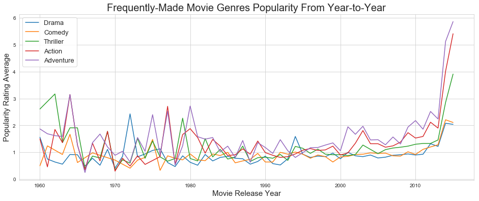

```python
# Set line chart table to a larger display size: (14, 6)
plt.figure(figsize=(16,6))

# Loop through each of the target_genres and plot the previous function
# extract_genre_popularity_by_year and the top five genres
for genre in target_genres:
    x,y = extract_genre_popularity_by_year(tmdb_df, genre)
    plt.plot(x,y)

# Format the line chart by adding a legend, a header title, the x and y axis titles,
# and display the graphed lines on a white gridded background to make viewing easier
plt.legend((target_genres), fontsize=13)
plt.title("Frequently-Made Movie Genres Popularity From Year-to-Year",fontsize=20)
plt.xlabel('Movie Release Year',fontsize=15)
plt.ylabel("Popularity Rating Average",fontsize=15)
sns.set_style("whitegrid")
plt.show()
```

> Adventure movies, which have had the least amount of movies made of the top five movie genres, have held the most recent popularity trend since as early as 2008-Current. Action movies follow closely behind in popularity.

### 2. Which movie genres had the highest revenues?

```python
# Define and print the shape and head of a list that contains
# genre and revenue data, set as genres_rev_df to use for later
genres_rev_df = tmdb_df[['genres','revenue']]
print(genres_rev_df.shape)
genres_rev_df.head()
```

```
(3854, 2)
```

|  | genres | revenue |
| --- | --- | --- |
| 0 | Action\|Adventure\|Science Fiction\|Thriller | 1513528810 |
| 1 | Action\|Adventure\|Science Fiction\|Thriller | 378436354 |
| 2 | Adventure\|Science Fiction\|Thriller | 295238201 |
| 3 | Action\|Adventure\|Science Fiction\|Fantasy | 2068178225 |
| 4 | Action\|Crime\|Thriller | 1506249360 |

```python
# Store count_genres in an ordered list using index
count_genres.index
```

```
Index(['Drama', 'Comedy', 'Thriller', 'Action', 'Adventure', 'Romance',
       'Crime', 'Science Fiction', 'Horror', 'Family', 'Fantasy', 'Mystery',
       'Animation', 'Music', 'History', 'War', 'Western', 'Documentary',
       'Foreign', 'TV Movie'],
      dtype='object')
```

```python
# Loop through each of the genres in count_genres.index from above and create a new
# varible called total_rev and store the results where the sum of the revenue for each
# genre in the genres_rev_df dataset can be called
total_genre_rev = list()
for genre in count_genres.index:
    total_rev = genres_rev_df[genres_rev_df['genres'].str.contains(genre)]['revenue'].sum()
# Append genre and total_rev to total_genre_rev
    total_genre_rev.append((genre, total_rev))
# Display
print(total_genre_rev)
```

[output not shown]

```python
# Create a new dataset using the data above, set genre and total_revenue to columns
# display the new shape of the df and print the first few rows and columns
genre_total_rev_df = pd.DataFrame(total_genre_rev, columns=['genre','total_revenue'])
print(genre_total_rev_df.shape)
genre_total_rev_df.head()
```

```
(20, 2)
```

|  | genre | total_revenue |
| --- | --- | --- |
| 0 | Drama | 130518678903 |
| 1 | Comedy | 132183056333 |
| 2 | Thriller | 117679517239 |
| 3 | Action | 169886215114 |
| 4 | Adventure | 163500596287 |

```python
# Create a new dataframe where the previous dataframe genre_total_rev_df is sorted in
# descending order by total_revenue amount, display first few rows and columns
sorted_genre_total_rev_df = genre_total_rev_df.sort_values(by='total_revenue', ascending=False)
sorted_genre_total_rev_df.head()
```

|  | genre | total_revenue |
| --- | --- | --- |
| 3 | Action | 169886215114 |
| 4 | Adventure | 163500596287 |
| 1 | Comedy | 132183056333 |
| 0 | Drama | 130518678903 |
| 2 | Thriller | 117679517239 |

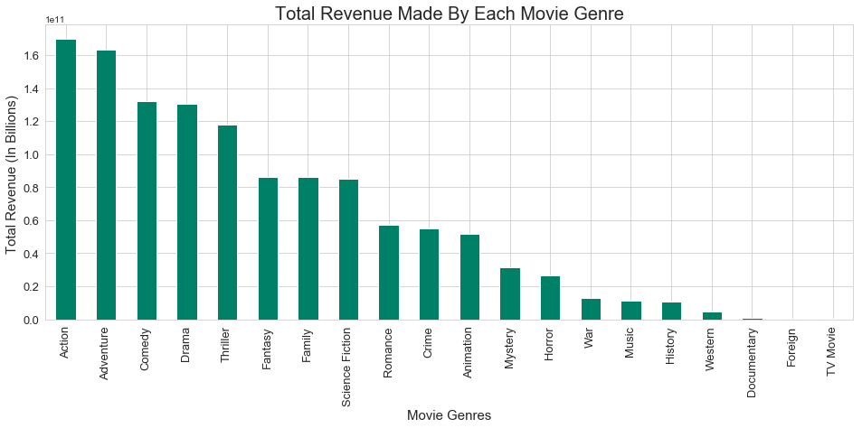

```python
# Plots the total revenue value of each movie genre using a bar chart
sorted_genre_total_rev_df.plot.bar(x = 'genre', y = 'total_revenue', figsize=(16,6), fontsize=13, colormap= 'summer')

# Add header title and x and y axis titles
plt.legend().remove()
plt.title("Total Revenue Made By Each Movie Genre",fontsize=20)
plt.xlabel('Movie Genres',fontsize=15)
plt.ylabel("Total Revenue (In Billions) ",fontsize=15)
sns.set_style("whitegrid")
```

> The top five most frequently-made movie genres, also hold the top spots for total revenue  
> produced.

### 3. Which director made the most movies?

```python
# Variable will store the return value from the split_data function
count_directors_df = split_counter(tmdb_df, 'director')

# Return leading movie directors and their counts
count_directors_df.head()
```

```
Steven Spielberg    28
Clint Eastwood      24
Ridley Scott        21
Woody Allen         18
Tim Burton          17
dtype: int64
```

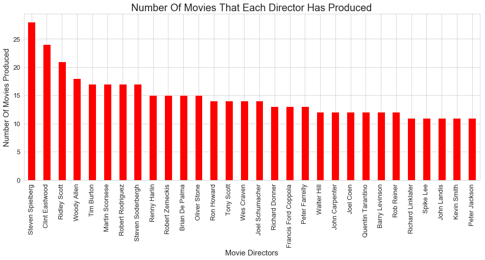

```python
# Plots the number of movies that each director has made using a bar chart
count_directors_df.iloc[:30].plot.bar(figsize=(16,6), fontsize=13, colormap= 'autumn')

# Add header title and x and y axis titles
plt.title("Number Of Movies That Each Director Has Produced",fontsize=20)
plt.xlabel('Movie Directors',fontsize=15)
plt.ylabel("Number Of Movies Produced",fontsize=15)
sns.set_style("whitegrid")
```

### 4. What movies had the greatest return on investment?

```python
# Create a dataset using the columns original_title, budget, and revenue
# display the shape of the dataset and the first few rows and columns
greatest_return_df = tmdb_df[['original_title', 'genres', 'budget', 'revenue']]
print(greatest_return_df.shape)
greatest_return_df.head()
```

```
(3854, 4)
```

|  | original_title | genres | budget | revenue |
| --- | --- | --- | --- | --- |
| 0 | Jurassic World | Action\|Adventure\|Science Fiction\|Thriller | 150000000 | 1513528810 |
| 1 | Mad Max: Fury Road | Action\|Adventure\|Science Fiction\|Thriller | 150000000 | 378436354 |
| 2 | Insurgent | Adventure\|Science Fiction\|Thriller | 110000000 | 295238201 |
| 3 | Star Wars: The Force Awakens | Action\|Adventure\|Science Fiction\|Fantasy | 200000000 | 2068178225 |
| 4 | Furious 7 | Action\|Crime\|Thriller | 190000000 | 1506249360 |

```python
# Create a new column called roi to store the results of the revenue minus the budget from the
# greatest_return_df to determine the return on investment of each movie produced and display
# the shape and first few rows and columns of df
greatest_return_df['roi'] = greatest_return_df['revenue'] - greatest_return_df['budget']
print(greatest_return_df.shape)
greatest_return_df.head()
```

```
(3854, 5)
```

|  | original_title | genres | budget | revenue | roi |
| --- | --- | --- | --- | --- | --- |
| 0 | Jurassic World | Action\|Adventure\|Science Fiction\|Thriller | 150000000 | 1513528810 | 1363528810 |
| 1 | Mad Max: Fury Road | Action\|Adventure\|Science Fiction\|Thriller | 150000000 | 378436354 | 228436354 |
| 2 | Insurgent | Adventure\|Science Fiction\|Thriller | 110000000 | 295238201 | 185238201 |
| 3 | Star Wars: The Force Awakens | Action\|Adventure\|Science Fiction\|Fantasy | 200000000 | 2068178225 | 1868178225 |
| 4 | Furious 7 | Action\|Crime\|Thriller | 190000000 | 1506249360 | 1316249360 |

```python
# Create a new df using the information from above, and sort the data by roi in descending order
# display the first few row and columns
sorted_roi_df = greatest_return_df.sort_values(by='roi', ascending=False)
movies_with_greatest_roi_df = sorted_roi_df.head()
movies_with_greatest_roi_df
```

|  | original_title | genres | budget | revenue | roi |
| --- | --- | --- | --- | --- | --- |
| 1386 | Avatar | Action\|Adventure\|Fantasy\|Science Fiction | 237000000 | 2781505847 | 2544505847 |
| 3 | Star Wars: The Force Awakens | Action\|Adventure\|Science Fiction\|Fantasy | 200000000 | 2068178225 | 1868178225 |
| 5231 | Titanic | Drama\|Romance\|Thriller | 200000000 | 1845034188 | 1645034188 |
| 0 | Jurassic World | Action\|Adventure\|Science Fiction\|Thriller | 150000000 | 1513528810 | 1363528810 |
| 4 | Furious 7 | Action\|Crime\|Thriller | 190000000 | 1506249360 | 1316249360 |

```python
count_genres_movies_roi = split_counter(movies_with_greatest_roi_df, 'genres')
count_genres_movies_roi.head()
```

```
Action             4
Science Fiction    3
Adventure          3
Thriller           3
Fantasy            2
dtype: int64
```

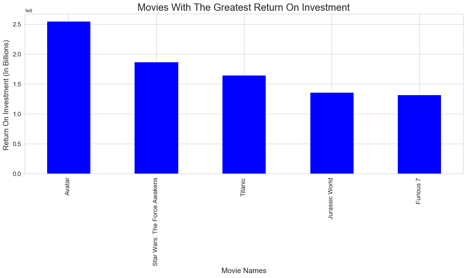

```python
# Plots movies with the greatest return on investment
movies_with_greatest_roi_df.plot.bar(x = 'original_title', y = 'roi', figsize=(16,6), fontsize=13, colormap= 'winter')

# Add header title and x and y axis titles
plt.legend().remove()
plt.title("Movies With The Greatest Return On Investment",fontsize=20)
plt.xlabel('Movie Names',fontsize=15)
plt.ylabel("Return On Investment (In Billions) ",fontsize=15)
sns.set_style("whitegrid")
```

### 5. Is there a relationship between movie popularity, return on investment, and genre?

```python
# Create a dataset using the columns original_title, genres, and popularity,
# display the shape of the dataset and the first few rows and columns
pop_genre_df = tmdb_df[['original_title', 'popularity']]
print(pop_genre_df.shape)
pop_genre_df.head()
```

```
(3854, 2)
```

|  | original_title | popularity |
| --- | --- | --- |
| 0 | Jurassic World | 32.985763 |
| 1 | Mad Max: Fury Road | 28.419936 |
| 2 | Insurgent | 13.112507 |
| 3 | Star Wars: The Force Awakens | 11.173104 |
| 4 | Furious 7 | 9.335014 |

```python
# Previous df from question 4 that determines the roi of each movie
greatest_return_df.head()
```

|  | original_title | genres | budget | revenue | roi |
| --- | --- | --- | --- | --- | --- |
| 0 | Jurassic World | Action\|Adventure\|Science Fiction\|Thriller | 150000000 | 1513528810 | 1363528810 |
| 1 | Mad Max: Fury Road | Action\|Adventure\|Science Fiction\|Thriller | 150000000 | 378436354 | 228436354 |
| 2 | Insurgent | Adventure\|Science Fiction\|Thriller | 110000000 | 295238201 | 185238201 |
| 3 | Star Wars: The Force Awakens | Action\|Adventure\|Science Fiction\|Fantasy | 200000000 | 2068178225 | 1868178225 |
| 4 | Furious 7 | Action\|Crime\|Thriller | 190000000 | 1506249360 | 1316249360 |

```python
# Merge the two datasets pop_genre_df and greatest_return_df
# using an inner join on the original_title varible
merged_df = pd.merge(pop_genre_df, greatest_return_df, how='inner', on='original_title')
print(merged_df.shape)
merged_df.head()
```

```
(3946, 6)
```

|  | original_title | popularity | genres | budget | revenue | roi |
| --- | --- | --- | --- | --- | --- | --- |
| 0 | Jurassic World | 32.985763 | Action\|Adventure\|Science Fiction\|Thriller | 150000000 | 1513528810 | 1363528810 |
| 1 | Mad Max: Fury Road | 28.419936 | Action\|Adventure\|Science Fiction\|Thriller | 150000000 | 378436354 | 228436354 |
| 2 | Insurgent | 13.112507 | Adventure\|Science Fiction\|Thriller | 110000000 | 295238201 | 185238201 |
| 3 | Star Wars: The Force Awakens | 11.173104 | Action\|Adventure\|Science Fiction\|Fantasy | 200000000 | 2068178225 | 1868178225 |
| 4 | Furious 7 | 9.335014 | Action\|Crime\|Thriller | 190000000 | 1506249360 | 1316249360 |

```python
# Creates a list named split_rows that loops through the merged dataframe (merged_df)
# and iterates each row with the results of the loop that splits/separates out the
# bar '|' symbol where it occurs in the genre column, appends to the list the split_rows list
split_rows = list()
for _, row in merged_df.iterrows():
    for genre in row['genres'].split('|'):
        split_rows.append((genre, row['popularity'], row['roi']))

print(len(split_rows))
# Slice indexing to print the first five elements in the array
print(split_rows[:5])
```

```
10556
[('Action', 32.985763, 1363528810), ('Adventure', 32.985763, 1363528810), ('Science Fiction', 32.985763, 1363528810), ('Thriller', 32.985763, 1363528810), ('Action', 28.419936, 228436354)]
```

```python
# Create a new dataset using the data above, set genre, 'popularity', and 'roi' to
# as columns, display the new shape of the df and print the first few rows and columns
genre_pop_roi_df = pd.DataFrame(split_rows, columns=['genre', 'popularity', 'roi'])
print(genre_pop_roi_df.shape)
genre_pop_roi_df.head()
```

```
(10556, 3)
```

|  | genre | popularity | roi |
| --- | --- | --- | --- |
| 0 | Action | 32.985763 | 1363528810 |
| 1 | Adventure | 32.985763 | 1363528810 |
| 2 | Science Fiction | 32.985763 | 1363528810 |
| 3 | Thriller | 32.985763 | 1363528810 |
| 4 | Action | 28.419936 | 228436354 |

```python
# Show the statistical data of the genre_pop_roi_df
genre_pop_roi_df.describe()
```

|  | popularity | roi |
| --- | --- | --- |
| count | 10556.000000 | 1.055600e+04 |
| mean | 1.266751 | 7.843859e+07 |
| std | 1.597587 | 1.650240e+08 |
| min | 0.001117 | -4.139124e+08 |
| 25% | 0.481188 | -1.444000e+06 |
| 50% | 0.853351 | 2.160924e+07 |
| 75% | 1.470363 | 9.187951e+07 |
| max | 32.985763 | 2.544506e+09 |

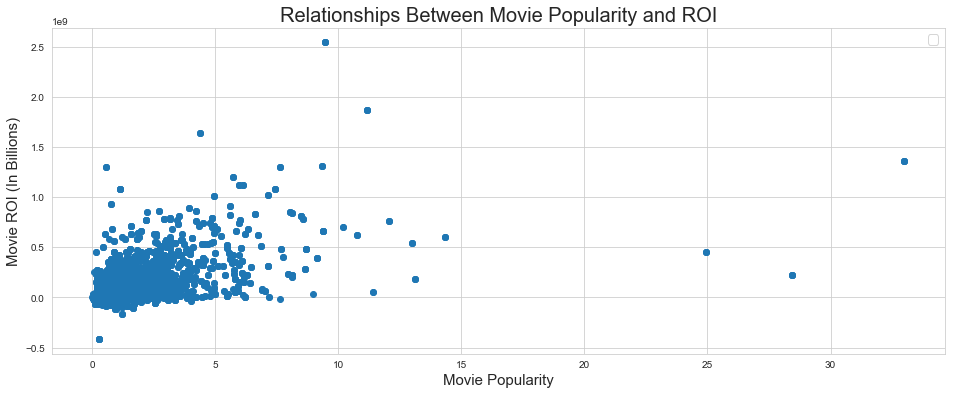

```python
# First scatter plot
# Set scatter plot table to a larger display size: (14, 6)
plt.figure(figsize=(16,6))

# Assign the genre_pop_roi_df for popularity to pop and
# genre_pop_roi_df for roi to roi to call later
pop = genre_pop_roi_df['popularity'].values
roi = genre_pop_roi_df['roi'].values

# Format the scatter plot by adding a header title, the x and y axis titles,
# and display the graphed lines on a white gridded background to make viewing easier
plt.legend((target_genres), fontsize=13)
plt.title("Relationships Between Movie Popularity and ROI",fontsize=20)
plt.xlabel('Movie Popularity',fontsize=15)
plt.ylabel("Movie ROI (In Billions)",fontsize=15)
sns.set_style("whitegrid")
plt.scatter(pop, roi)
plt.show()
```

```python
# Display target_genres
print(target_genres)
```

```
Index(['Drama', 'Comedy', 'Thriller', 'Action', 'Adventure'], dtype='object')
```

```python
# Assign a color code to each of the genres in target_genres
genre_colors = {
    'Action': 'blue',
    'Adventure': 'green',
    'Comedy': 'yellow',
    'Drama': 'red',
    'Thriller': 'purple'
}
```

```
(2687, 3)
```

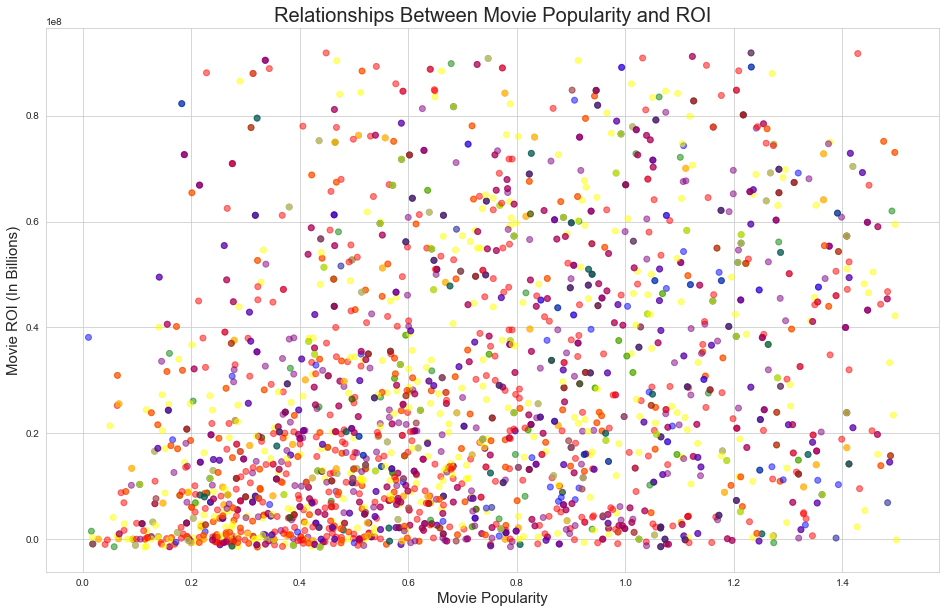

```python
# Second scatter plot
# Focus target genres, popularity <= 1.5, and roi >= -1.5e6 & <= 9.2e7.
trimmed_pop_df = genre_pop_roi_df[(genre_pop_roi_df['genre'].isin(target_genres)) & (genre_pop_roi_df['popularity'] <= 1.5) & (genre_pop_roi_df['roi'] >= -1.5e6) & (genre_pop_roi_df['roi'] <= 9.2e7)]
print(trimmed_pop_df.shape)
pop = trimmed_pop_df['popularity'].values
roi = trimmed_pop_df['roi'].values

plt.figure(figsize=(16,10))
ax = plt.subplot(111)
plt.title("Relationships Between Movie Popularity and ROI",fontsize=20)
# Format the scatter plot by adding a header title, the x and y axis titles,
# and display the graphed lines on a white gridded background to make viewing easier
plt.xlabel('Movie Popularity',fontsize=15)
plt.ylabel("Movie ROI (In Billions)",fontsize=15)
plt.scatter(pop, roi, c=trimmed_pop_df['genre'].apply(lambda genre: genre_colors[genre]), alpha=0.5)
plt.show()
```

## Conclusions

> A1. Since the 1960-current, the top five most frequently-made movie genres are, in order are: Drama, Comedy, Thriller, Action, and Adventure. However, even though Drama, Comedy, and Thriller movies have had more movies made than Adventure and Action movies, Adventure and Action movies have held the most recent popularity trend since as early as 2008-current (for about a decade). An Adventure/Action movie is more likely to result in a higher popularity rating.

> A3. Of the movie producers in the dataset, Steven Spielberg has produced the most. I did this more for curiosity, but a deeper analysis could be performed.

> A4. Movies that had the greatest return on investment were, in order: Avatar, Star Wars: The Force Awakens, Titanic, Jurassic World, and Furious 7. Of the top movies with the greatest return on investment, Action was the most prominent occurrence in these movies counting for 4 out of 5 movie genres. Other genre factors were Science Fiction 3/5, Adventure 3/5, Thriller 3/5, and Fantasy 2/5.

> A5. While many of the movies were blockbusters in the dataset, and some considerered outliers, the data visualization that I generated suggests that there is not a strong coorolation between movie popularity, return on investment, and genre. The spread was pretty consistant throughout the data.

##### Limitations

> Since the dataset wasn't completely clean from the start, I had to drop a number of rows which may have shifted the results of the analysis a bit. Additionally, outliers had to be dropped for the final scatter plot, as they shifted the results of the visualization.

#### Sources

> https://pandas.pydata.org/pandas-docs/stable/generated/pandas.to_datetime.html

> https://stackoverflow.com/questions/31468176/setting-values-on-a-copy-of-a-slice-from-a-dataframe?rq=1

> https://matplotlib.org/gallery/statistics/barchart_demo.html

> https://stackoverflow.com